# Bacteriophage T7 RNA Polymerase / Dna-Directed RNA Polymerase

Fold-switch pair **1qlnA_1h38D** — **1qlnA** vs **1h38D**

Escherichia phage T7

## Figure 1: Phylogenetic tree with per-cluster fold-preference heatmap.

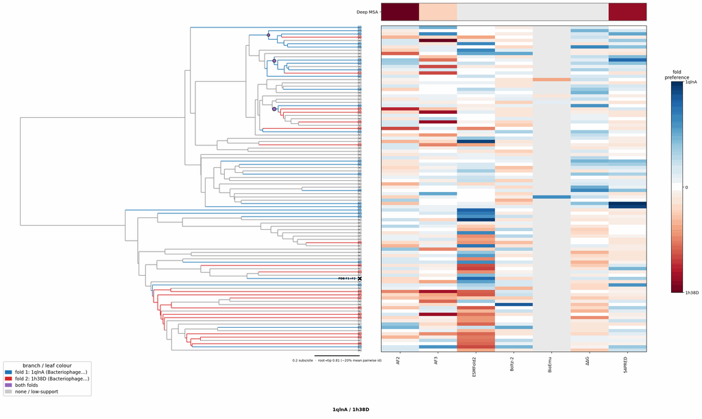

## Figure 2: Aligned overlay (both folds superposed)

The single fold-switching chain of each fold superposed by TM-align; waters hidden, any ligand shown as green sticks. Grey = structurally conserved core, colour = divergent (fold-switching) region.

1qlnA (Bacteriophage T7 RNA Polymerase / Dna-Directed RNA Polymerase) · dimer1h38D (Bacteriophage T7 RNA Polymerase / Dna-Directed RNA Polymerase) · monomerLigand GTP (bound to 1qlnA)

TM-score: 0.730 · Trigger class: protein_binding

Aligned overlay

Loading...

## Figure 3: The two folds, side by side

Each fold is coloured by per-residue Cα deviation between the two superposed structures: grey ≈ conserved core, full colour = structurally divergent (fold-switching) region.

1qlnA (Bacteriophage T7 RNA Polymerase / Dna-Directed RNA Polymerase)

1h38D (Bacteriophage T7 RNA Polymerase / Dna-Directed RNA Polymerase)

0 Å5≥10 Å

1qlnA (Bacteriophage T7 RNA Polymerase / Dna-Directed RNA Polymerase)

Loading...

1h38D (Bacteriophage T7 RNA Polymerase / Dna-Directed RNA Polymerase)

Loading...

## Figure 4: Best-cluster predicted contact maps over the two true folds.

Predicted contact maps (MSA-Transformer) for the clusters best matching each fold, over the true contacts of fold 1 (upper triangle) and fold 2 (lower). Divergent contacts between clusters are the contact-level signature of fold-switching.

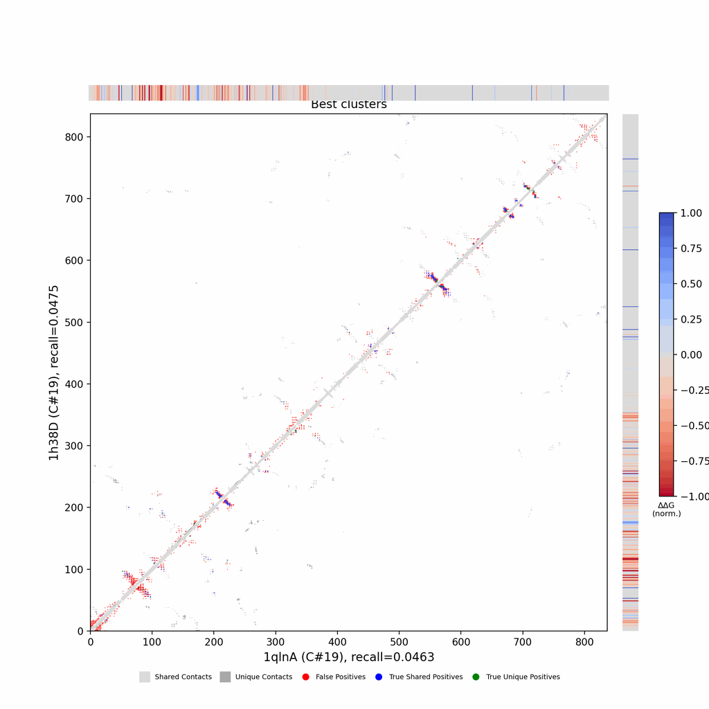

## Figure 5: Per-residue ΔΔG fold-preference contribution

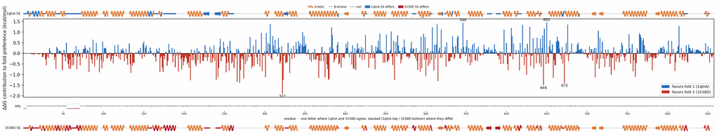

**More figures**

## Figure 6: Deep-MSA contact map panel / Best clusters contact map panel

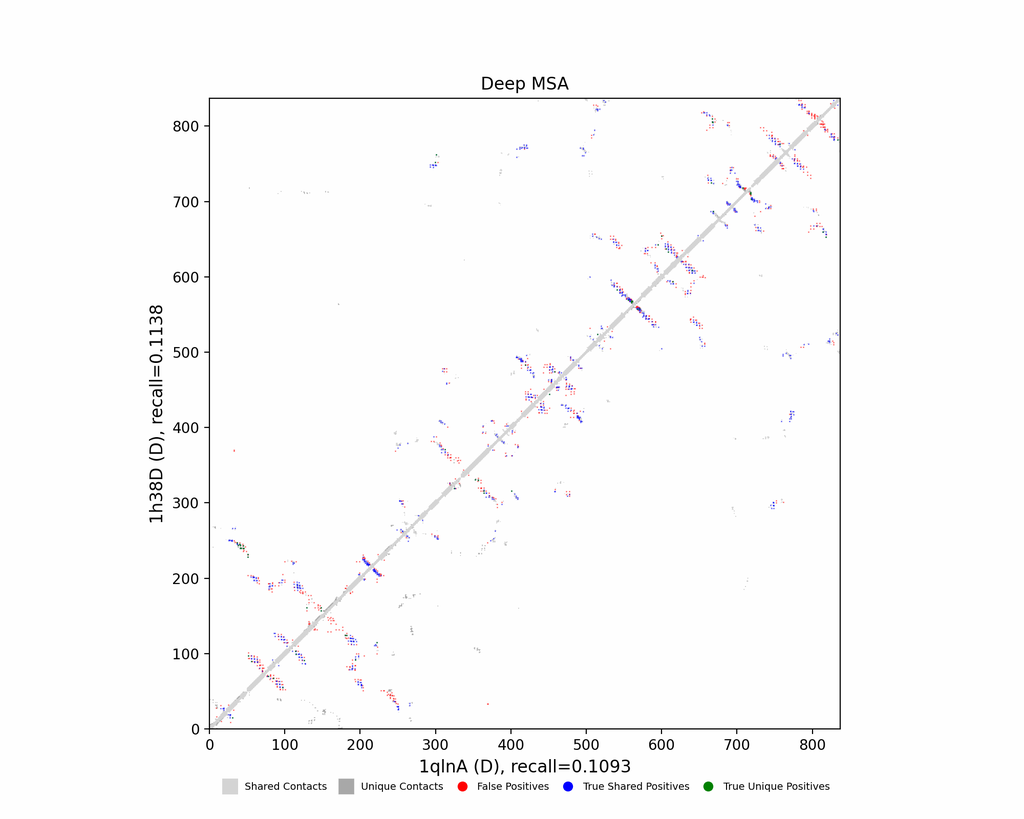

Deep-MSA contact map panel

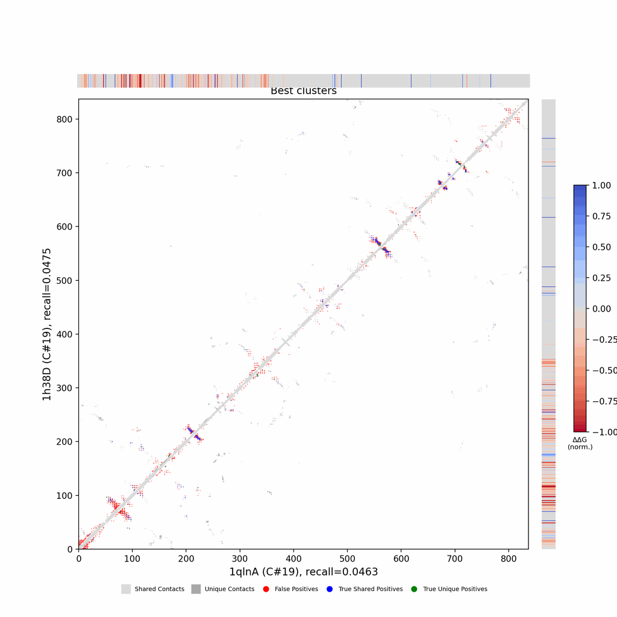

Best clusters contact map panel

## Figure 7: All clusters contact-map mosaic (small multiples).

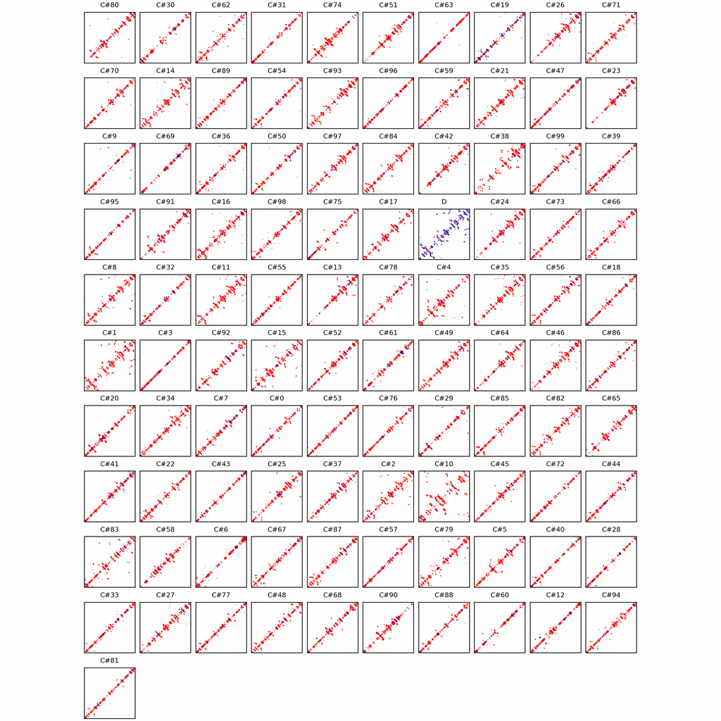

## Figure 8: Phylo null: tree with shuffled cluster fold labels.

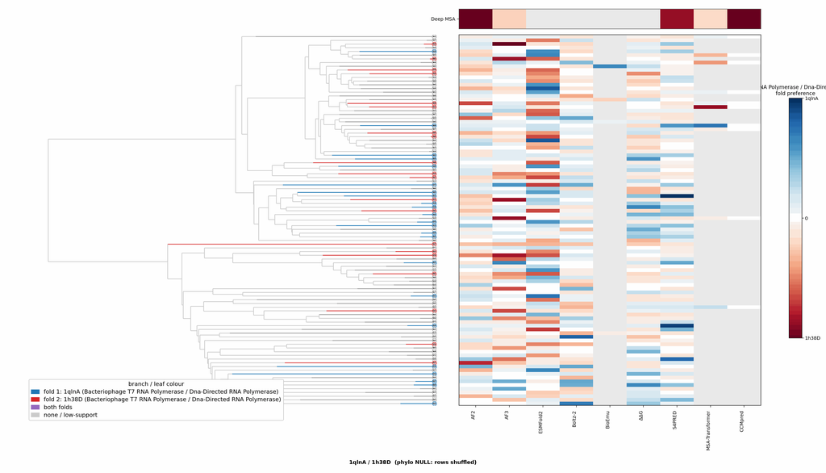

## Cluster metrics table

Per-cluster metrics underlying the figures above.

| cluster | n | neff | AF2_TM1 | AF2_TM2 | AF3_TM1 | AF3_TM2 | RE-MSAT-COM | RE-MSAT1 | RE-MSAT2 | ESM_SEQIDS | ESM_TM1 | ESM_TM2 | ΔΔG_Bias | ΔΔG_Bias_std | ΔΔG_frac_F1 | Boltz2_pref | S4PRED_pref | CCMpred_pref | BioEmu_pref |
| --- | --- | --- | --- | --- | --- | --- | --- | --- | --- | --- | --- | --- | --- | --- | --- | --- | --- | --- | --- |
| Deep | - | - | 0.83 | 0.94 | 0.9 | 0.94 | 0.44 | 0.41 | 0.43 | - | - | - | - | - | - | - | -0.04 | -0.0 | - |
| 000 | 522.0 | 67.0 | 0.29 | 0.27 | 0.25 | 0.27 | 0.0 | 0.0 | 0.0 | 002; 003; 001; 004; 007; 008; 005; 009; 006; 010 | 0.57 ± 0.20 | 0.57 ± 0.21 | -39.98 | 17.29 | 0.0 | 0.02 | -0.03 | - | - |
| 001 | 401.0 | 222.0 | 0.3 | 0.29 | 0.33 | 0.34 | 0.01 | 0.01 | 0.01 | 002; 007; 002; 007; 005; 005; 004; 004; 001; 001 | 0.74 ± 0.03 | 0.72 ± 0.05 | -36.67 | 26.14 | 0.2 | 0.02 | -0.03 | 0.0 | - |
| 002 | 184.0 | 96.0 | 0.33 | 0.34 | 0.56 | 0.55 | 0.01 | 0.01 | 0.01 | 001; 001; 004; 004; 003; 003; 005; 005; 002; 002 | 0.77 ± 0.05 | 0.72 ± 0.04 | -33.46 | 23.14 | 0.1 | 0.0 | -0.03 | 0.0 | - |
| 003 | 169.0 | 27.0 | 0.22 | 0.21 | 0.28 | 0.24 | 0.0 | 0.0 | 0.0 | 001; 001; 002; 002; 005; 005; 009; 009; 004; 004 | 0.72 ± 0.04 | 0.73 ± 0.07 | -31.58 | 20.56 | 0.1 | 0.02 | -0.03 | 0.0 | - |
| 004 | 141.0 | 83.0 | 0.27 | 0.28 | 0.81 | 0.76 | 0.01 | 0.01 | 0.01 | 001; 001; 004; 004; 005; 005; 006; 006; 003; 008 | 0.74 ± 0.05 | 0.75 ± 0.08 | -28.59 | 24.3 | 0.2 | 0.02 | -0.03 | 0.0 | - |
| 005 | 133.0 | 65.0 | 0.24 | 0.27 | 0.3 | 0.27 | 0.01 | 0.01 | 0.01 | 008; 008; 006; 006; 007; 007; 003; 009; 009; 003 | 0.69 ± 0.02 | 0.64 ± 0.00 | -33.68 | 18.63 | 0.1 | 0.02 | -0.03 | 0.0 | - |
| 006 | 120.0 | 8.0 | 0.22 | 0.24 | 0.22 | 0.22 | 0.0 | 0.0 | 0.0 | 006; 006; 002; 001; 001; 002; 004; 004; 009; 003 | 0.72 ± 0.04 | 0.69 ± 0.05 | -20.72 | 13.99 | 0.2 | -0.01 | -0.02 | 0.0 | - |
| 007 | 97.0 | 33.0 | 0.28 | 0.26 | 0.32 | 0.32 | 0.01 | 0.01 | 0.02 | 008; 007; 008; 002; 007; 002; 006; 006; 003; 003 | 0.71 ± 0.03 | 0.62 ± 0.01 | -19.31 | 13.14 | 0.2 | 0.02 | -0.02 | 0.0 | - |
| 008 | 88.0 | 43.0 | 0.26 | 0.33 | 0.5 | 0.48 | 0.01 | 0.01 | 0.01 | 001; 003; 001; 003; 002; 002; 008; 008; 007; 007 | 0.71 ± 0.04 | 0.71 ± 0.06 | -29.51 | 22.28 | 0.2 | 0.02 | -0.04 | 0.0 | - |
| 009 | 87.0 | 26.0 | 0.21 | 0.19 | 0.28 | 0.25 | 0.0 | 0.0 | 0.01 | 005; 005; 002; 002; 007; 007; 004; 004; 006; 006 | 0.70 ± 0.04 | 0.74 ± 0.08 | -42.04 | 10.66 | 0.0 | 0.03 | -0.01 | 0.0 | - |
| 010 | 81.0 | 57.0 | 0.65 | 0.63 | 0.75 | 0.92 | 0.02 | 0.01 | 0.03 | 001; 001; 002; 002; 007; 007; 008; 008; 004; 004 | 0.66 ± 0.11 | 0.63 ± 0.09 | -19.77 | 32.65 | 0.5 | -0.0 | -0.04 | 0.0 | - |
| 011 | 80.0 | 58.0 | 0.69 | 0.7 | 0.81 | 0.94 | 0.0 | 0.01 | 0.0 | - | - | - | -30.62 | 23.65 | 0.2 | 0.02 | -0.04 | - | - |
| 012 | 78.0 | 12.0 | 0.27 | 0.23 | 0.27 | 0.25 | 0.0 | 0.0 | 0.0 | - | - | - | -15.77 | 11.85 | 0.1 | 0.01 | -0.01 | - | - |
| 013 | 75.0 | 35.0 | 0.24 | 0.25 | 0.38 | 0.36 | 0.01 | 0.01 | 0.01 | - | - | - | -16.47 | 21.3 | 0.3 | 0.02 | -0.03 | - | - |
| 014 | 75.0 | 45.0 | 0.2 | 0.19 | 0.33 | 0.34 | 0.0 | 0.0 | 0.01 | - | - | - | -33.43 | 23.28 | 0.2 | -0.01 | -0.04 | - | 0.01 |
| 015 | 68.0 | 39.0 | 0.42 | 0.42 | 0.57 | 0.57 | 0.02 | 0.01 | 0.02 | - | - | - | -9.33 | 16.8 | 0.3 | 0.04 | -0.03 | - | - |
| 016 | 68.0 | 37.0 | 0.3 | 0.28 | 0.64 | 0.73 | 0.01 | 0.01 | 0.01 | - | - | - | -35.26 | 22.51 | 0.2 | 0.01 | -0.04 | - | - |
| 017 | 67.0 | 45.0 | 0.22 | 0.2 | 0.24 | 0.24 | 0.01 | 0.01 | 0.01 | - | - | - | -17.32 | 16.29 | 0.2 | 0.0 | -0.02 | - | - |
| 018 | 66.0 | 23.0 | 0.19 | 0.21 | 0.25 | 0.24 | 0.0 | 0.0 | 0.0 | - | - | - | -9.68 | 15.92 | 0.3 | 0.02 | -0.03 | - | - |
| 019 | 66.0 | 15.0 | 0.2 | 0.22 | 0.27 | 0.27 | 0.15 | 0.14 | 0.15 | - | - | - | -23.56 | 24.3 | 0.3 | -0.0 | -0.02 | - | - |
| 020 | 65.0 | 22.0 | 0.24 | 0.24 | 0.26 | 0.22 | 0.01 | 0.01 | 0.01 | - | - | - | -12.42 | 9.42 | 0.1 | 0.02 | -0.02 | - | - |
| 021 | 61.0 | 39.0 | 0.65 | 0.67 | 0.75 | 0.91 | 0.01 | 0.01 | 0.01 | - | - | - | -35.92 | 26.24 | 0.2 | 0.01 | -0.03 | - | - |
| 022 | 60.0 | 14.0 | 0.23 | 0.22 | 0.33 | 0.34 | 0.01 | 0.01 | 0.01 | - | - | - | -34.51 | 18.06 | 0.0 | 0.02 | -0.03 | - | - |
| 023 | 57.0 | 27.0 | 0.26 | 0.26 | 0.56 | 0.56 | 0.02 | 0.01 | 0.02 | - | - | - | -21.05 | 34.78 | 0.5 | -0.01 | -0.03 | - | - |
| 024 | 56.0 | 30.0 | 0.27 | 0.23 | 0.37 | 0.37 | 0.01 | 0.0 | 0.01 | - | - | - | -30.51 | 19.24 | 0.1 | -0.02 | -0.03 | - | - |
| 025 | 55.0 | 42.0 | 0.24 | 0.24 | 0.44 | 0.44 | 0.01 | 0.01 | 0.01 | - | - | - | -18.8 | 30.23 | 0.4 | -0.0 | -0.03 | - | -0.0 |
| 026 | 54.0 | 34.0 | 0.24 | 0.22 | 0.53 | 0.52 | 0.01 | 0.01 | 0.01 | - | - | - | -28.87 | 26.58 | 0.3 | -0.01 | -0.03 | - | - |
| 027 | 54.0 | 31.0 | 0.73 | 0.81 | 0.86 | 0.91 | 0.02 | 0.02 | 0.02 | - | - | - | -36.34 | 19.22 | 0.1 | 0.0 | -0.02 | - | - |
| 028 | 53.0 | 21.0 | 0.2 | 0.21 | 0.6 | 0.57 | 0.01 | 0.01 | 0.01 | - | - | - | -38.33 | 15.97 | 0.0 | -0.0 | -0.03 | - | - |

[output cut: 71 more lines]